# Project: TMDb movie data

## Exploratory Data Analysis

> **Tip**: Now that you've trimmed and cleaned your data, you're ready to move on to exploration. Compute statistics and create visualizations with the goal of addressing the research questions that you posed in the Introduction section. It is recommended that you be systematic with your approach. Look at one variable at a time, and then follow it up by looking at relationships between variables.

```python
films.head(5)
```

|  | budget | revenue | original_title | cast | director | tagline | runtime | genres | release_date | release_year |
| --- | --- | --- | --- | --- | --- | --- | --- | --- | --- | --- |
| 0 | 150000000.0 | 1.513529e+09 | Jurassic World | Chris Pratt\|Bryce Dallas Howard\|Irrfan Khan\|Vi... | Colin Trevorrow | The park is open. | 124 | Action\|Adventure\|Science Fiction\|Thriller | 6/9/15 | 2015 |
| 1 | 150000000.0 | 3.784364e+08 | Mad Max: Fury Road | Tom Hardy\|Charlize Theron\|Hugh Keays-Byrne\|Nic... | George Miller | What a Lovely Day. | 120 | Action\|Adventure\|Science Fiction\|Thriller | 5/13/15 | 2015 |
| 2 | 110000000.0 | 2.952382e+08 | Insurgent | Shailene Woodley\|Theo James\|Kate Winslet\|Ansel... | Robert Schwentke | One Choice Can Destroy You | 119 | Adventure\|Science Fiction\|Thriller | 3/18/15 | 2015 |
| 3 | 200000000.0 | 2.068178e+09 | Star Wars: The Force Awakens | Harrison Ford\|Mark Hamill\|Carrie Fisher\|Adam D... | J.J. Abrams | Every generation has a story. | 136 | Action\|Adventure\|Science Fiction\|Fantasy | 12/15/15 | 2015 |
| 4 | 190000000.0 | 1.506249e+09 | Furious 7 | Vin Diesel\|Paul Walker\|Jason Statham\|Michelle ... | James Wan | Vengeance Hits Home | 137 | Action\|Crime\|Thriller | 4/1/15 | 2015 |

### Runtime of Movies

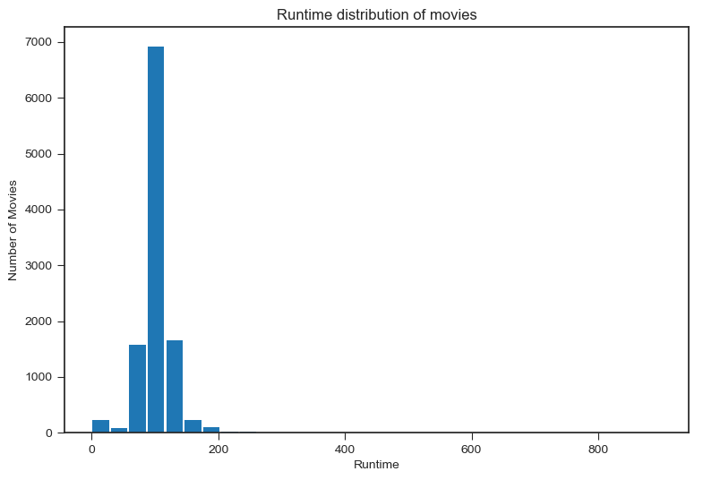

```python
#plotting a histogram of runtime of movies

#gives styles
sns.set_style('ticks')

#changing the label size
plt.rc('xtick', labelsize = 10)
plt.rc('ytick', labelsize = 10)

plt.figure(figsize=(9,6), dpi = 100)
plt.title('Runtime distribution of movies')
plt.ylabel('Number of Movies')
plt.xlabel('Runtime')
plt.hist(films['runtime'], rwidth = 0.9, bins =31)
plt.show()
```

#### Which variables are linked with the revenues of films during the years? If so, how?

```python
imdb = pd.read_csv('tmdb-movies.csv')
new_df = imdb.groupby('release_year').mean()
new_df.corr(method='pearson')
```

|  | id | popularity | budget | revenue | runtime | vote_count | vote_average | budget_adj | revenue_adj |
| --- | --- | --- | --- | --- | --- | --- | --- | --- | --- |
| id | 1.000000 | 0.611184 | 0.099922 | 0.151857 | -0.444906 | 0.539784 | -0.296016 | -0.148934 | -0.300431 |
| popularity | 0.611184 | 1.000000 | 0.668278 | 0.759204 | -0.489135 | 0.849119 | -0.573969 | 0.459301 | -0.100096 |
| budget | 0.099922 | 0.668278 | 1.000000 | 0.905987 | -0.400676 | 0.782140 | -0.731565 | 0.891844 | -0.158444 |
| revenue | 0.151857 | 0.759204 | 0.905987 | 1.000000 | -0.465069 | 0.809073 | -0.705986 | 0.767218 | 0.075258 |
| runtime | -0.444906 | -0.489135 | -0.400676 | -0.465069 | 1.000000 | -0.613270 | 0.523926 | -0.071570 | 0.301877 |
| vote_count | 0.539784 | 0.849119 | 0.782140 | 0.809073 | -0.613270 | 1.000000 | -0.657132 | 0.505548 | -0.215771 |
| vote_average | -0.296016 | -0.573969 | -0.731565 | -0.705986 | 0.523926 | -0.657132 | 1.000000 | -0.558121 | 0.376702 |
| budget_adj | -0.148934 | 0.459301 | 0.891844 | 0.767218 | -0.071570 | 0.505548 | -0.558121 | 1.000000 | 0.050550 |
| revenue_adj | -0.300431 | -0.100096 | -0.158444 | 0.075258 | 0.301877 | -0.215771 | 0.376702 | 0.050550 | 1.000000 |

### Revenue vs Popularity using a scatterplot

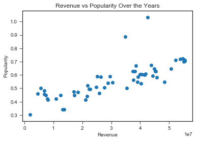

```python
# Creating a scatterplot of revenue and popularity over the years
plt.scatter(x=new_df['revenue'], y=new_df['popularity'])
plt.xlabel('Revenue')
plt.ylabel('Popularity')
plt.title('Revenue vs Popularity Over the Years');
```

#### Observations:

The correlation computed from function is evident in the scatterplot. Popularity is proportional to revenues. The few outliers that grossed medium but were rated extremely high need to be looked into.

#### Biggest and smallest runtime

```python
big_small('runtime')
```

|  | 3894 | 92 |
| --- | --- | --- |
| budget | NaN | NaN |
| revenue | NaN | NaN |
| original_title | The Story of Film: An Odyssey | Mythica: The Necromancer |
| cast | Mark Cousins\|Jean-Michel Frodon\|Cari Beauchamp... | Melanie Stone\|Adam Johnson\|Kevin Sorbo\|Nicola ... |
| director | Mark Cousins | A. Todd Smith |
| tagline | NaN | NaN |
| runtime | 900 | 0 |
| genres | Documentary | Fantasy\|Action\|Adventure |
| release_date | 9/3/11 | 12/19/15 |
| release_year | 2011 | 2015 |

#### Vote vs Revenue counts:

Here, we view how vote counts and revenue are related using a scatterplot.

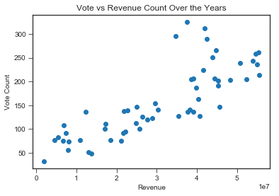

```python
# Creating a scatterplot of revenue and vote counts over the years
plt.scatter(x=new_df['revenue'], y=new_df['vote_count'])
plt.xlabel('Revenue')
plt.ylabel('Vote Count')
plt.title('Vote vs Revenue Count Over the Years');
```

#### Observations- Revenue vs Vote Count:

The correlation computed from function is evident in the scatterplot. Vote count is roughly proportional to revenues. Even in this plot, we observe that a few sample had high counts but did not gross commensurately in revenue. This plot points us to scrutinize the vote counts and type of votes if possible or any other factors influencing voting such as genres, cast, etc.

#### The mean runtime of all movies:

```python
def avg(column_name):
    return films[column_name].mean()
avg('runtime')
```

```
102.07086324314375
```

### Vote vs Revenue averages:

Here, we visualize how vote averages and revenue are related using a scatterplot.

```
Text(0.5,1,u'Vote  vs  Revenue   Averages  Over  the  Years')
```

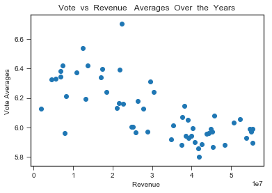

```python
# Creating a scatterplot of revenue and vote averages over the years
plt.scatter (x=new_df['revenue'], y=new_df['vote_average'])
plt.ylabel ('Vote Averages ')
plt.xlabel ('Revenue ')
plt.title ('Vote  vs  Revenue   Averages  Over  the  Years')
```

#### Observations:

The correlation computed from function is evident in the scatterplot. Vote averages are inversely proportional to revenues. Considering this plot and the previous, we can infer voting variables as influencing revenues. This means that detailed analysis is required to assess the outliers and possibly pursue a detailed line of investigation based on vote counts and averages.

## Conclusions

### Limitations

1. In case of varying currencies [which is likely since the movies range from different regions], exchange rates or conversions or some sort of normalization would need to be applied.
2. Vote counts are taken at face value. We are not inspecting the nature of votes, good or bad or any other range of values. Also, the period or channels in which these vote counts were gathered is not considered and will be significant if varying for different movies.
3. This analysis assumes that the same index and methods were employed for collecting popularity factors and counting votes for all movies. In the event that it is not so, the results might not hold true.
4. The medium through which popularity was determined is unknown. This can impact the analysis as the limitations and bias inherent while gauging audience response will be present in the end values too.